# Credit Risk Prediction

## ML Course Project

### Group Name: NoSteakStuds

#### Group Members: Kanishk Jain (s3810978), Shivangi Agrawal (s3802226)

## Objective

The objective of this project is to predict if an applicant is a good or bad credit risk. Classification method is used for this purpose. Different classificastion models are employed and data is fit into each one of them. Accuracy for each model is calculated and best model is deduced for future prediction. The dataset is taken from UCI Machine Learning Repository.

#### 1. Overview

- 1.1 Methodology
  - 1.1.1 Data Preparation Steps
  - 1.1.2 Feature Engineering
  - 1.1.3 Splitting the data and Modelling

#### 2. Data Description

- 2.1 Descriptive Feature Descriptions
- 2.2 Target Feature Description

#### 3. Data Preprocessing

- 3.1 Loading Dataset
- 3.2 Checking datatypes
- 3.3 Summary Statistics
- 3.4 Converting datatypes
- 3.5 Renaming categories
- 3.6 Checking for Missing Values
- 3.7 Sanity Checks
- 3.8 Checking for Extra Whitespace
- 3.9 Removing unwanted single quotes
- 3.10 Discretizing

#### 4. Data Exploration

- 4.1 One-variable Plots
- 4.2 Two-variable Plots
- 4.3 Three-variable Plots

#### 5. Preparing Data for Modelling

- 5.1 Converting Datatypes
- 5.2 Separating Target Feature
- 5.3 Label Encoding
- 5.4 One-hot encoding
- 5.5 Scaling

#### 6. Feature Selection & Ranking

- 6.1 RFI
- 6.2 Calculating importance scores of features

#### 7. Data Splitting

#### 8. Hyperparameter Tuning

- 8.1 6-fold cross-validation
- 8.2 Defining feature selector function

#### 9. K-Nearest Neighbours (K-NN)

- 9.1 Pipeline and Grid search
- 9.2 Visualizing scores of models with different parameters

#### 10. Decision Tree

- 10.1 Pipeline and Grid search
- 10.2 Visualizing scores of models with different parameters

#### 11. Naive Bayes

- 11.1 Pipeline and Grid search
- 11.2 Visualizing scores of models with different parameters

#### 12. Random Forest

- 12.1 Pipeline and Grid search
- 12.2 Visualizing scores of models with different parameters

#### 15. Summary and Conclusion

#### 16. References

## 1. Overview

The data is prepared for classification, encoded using 'One-Hot Encoding' and then split into testing and training datasets. The data is then fit into different classifiers used for prediction. Accuracy of each model is calculated and we get the best classification model for future unseen data.

### 1.1 Methodology

Four binary classifiers are employed for prediction:

## 2. Data Description

The Dataset ‘credit-g’, imported from UCI Machine Learning Repository (https://archive.ics.uci.edu/ml/datasets/statlog+(german+credit+data), is a German Credit data, that helps the banks in classifying people as good or bad credit risk. The dataset consists of 20 descriptive features and 1 target feature ‘class’. It is a mixture of both numeric (7) and nominal (14) features, which together help in predicting if a customer is good or bad risk. Further, there are 1000 rows in the dataset. We use various parameters in order to arrive at a decision, like age, personal status, employment history, etc.

### 2.1 Descriptive Feature Descriptions:

- Checking_status-It provides information regarding the amount in the checking account(in Deutshe Mark)
- Duration-duration of credit(in months)
- Credit_history-The previous credit history of customer
- Purpose-purpose of credit requirement
- Credit_amount-The amount of credit required
- savings_status-The amount of savings and bonds customer might be having
- employment-no of years of employment
- installment_commitment-The rate of installment
- Personal_status-Describes the gender and married or single
- Other_parties-Any other debtors and guarantors
- residence_since-no of years of residence
- Property_magnitude-Informstion about the property of the customer
- Age-Age(in years)
- Other_payment_plans-Any other installment plans that the customer might be having
- Housing-Living status of the customer
- existing_credits-No of existing credits in the current bank
- Job-Job description of the customer(sector)
- Num_dependents-No of people the person is responsible for
- Own_telephone-If customer is having a telephone or not
- Foreign_worker-If customer is a foreign worker or not

### 2.2 Target Feature Description:

The target feature is 'class'. There are 2 possible values of class:

- Good (Positive)
- Bad (Negative)

The goal here is to predict whether an applicant is good or bad credit risk.

## 3. Data pre-processing:

In this part, the dataset is pre-processed in order to make it fit for exploration and modelling.

### 3.1 Loading Dataset:

First, all the necessary packages are installed in order to perform various functions on the dataset. The dataset, ‘credit-g’ is loaded in the python work space using, pandas function ‘pd.read_csv()’ and is named as ‘crdt’. Then the data is analysed using ‘head()’ function and data types are observed using ‘.dtypes’ function.

```python
import warnings
warnings.filterwarnings('ignore')
import io
import requests
import ssl
seed_value = 999
import os
os.environ['PYTHONHASHSEED']=str(seed_value)
import random
random.seed(seed_value)
import numpy as np
np.random.seed(seed_value)
import pandas as pd
pd.set_option('display.max_columns', None)
import matplotlib.pyplot as plt
import seaborn as sns
import patsy
plt.style.use("ggplot")
%matplotlib inline
%config InlineBackend.figure_format = 'retina'
```

```python
%%capture
!pip install --upgrade altair
!pip install vega vega_datasets
!pip install --upgrade pip
```

```python
import altair as alt
alt.renderers.enable('notebook')
```

```
RendererRegistry.enable('notebook')
```

```python
crdt=pd.read_csv("s3810978_s3802226_Data.csv")
```

```python
crdt.head(5)
```

|  | checking_status | duration | credit_history | purpose | credit_amount | savings_status | employment | installment_commitment | personal_status | other_parties | residence_since | property_magnitude | age | other_payment_plans | housing | existing_credits | job | num_dependents | own_telephone | foreign_worker | class |
| --- | --- | --- | --- | --- | --- | --- | --- | --- | --- | --- | --- | --- | --- | --- | --- | --- | --- | --- | --- | --- | --- |
| 0 | '<0' | 6 | 'critical/other existing credit' | radio/tv | 1169 | 'no known savings' | '>=7' | 4 | 'male single' | none | 4 | 'real estate' | 67 | none | own | 2 | skilled | 1 | yes | yes | good |
| 1 | '0<=X<200' | 48 | 'existing paid' | radio/tv | 5951 | '<100' | '1<=X<4' | 2 | 'female div/dep/mar' | none | 2 | 'real estate' | 22 | none | own | 1 | skilled | 1 | none | yes | bad |
| 2 | 'no checking' | 12 | 'critical/other existing credit' | education | 2096 | '<100' | '4<=X<7' | 2 | 'male single' | none | 3 | 'real estate' | 49 | none | own | 1 | 'unskilled resident' | 2 | none | yes | good |
| 3 | '<0' | 42 | 'existing paid' | furniture/equipment | 7882 | '<100' | '4<=X<7' | 2 | 'male single' | guarantor | 4 | 'life insurance' | 45 | none | 'for free' | 1 | skilled | 2 | none | yes | good |
| 4 | '<0' | 24 | 'delayed previously' | 'new car' | 4870 | '<100' | '1<=X<4' | 3 | 'male single' | none | 4 | 'no known property' | 53 | none | 'for free' | 2 | skilled | 2 | none | yes | bad |

### 3.2 Checking datatypes:

We check the datatypes of all features.

```python
crdt.dtypes
```

```
checking_status           object
duration                   int64
credit_history            object
purpose                   object
credit_amount              int64
savings_status            object
employment                object
installment_commitment     int64
personal_status           object
other_parties             object
residence_since            int64
property_magnitude        object
age                        int64
other_payment_plans       object
housing                   object
existing_credits           int64
job                       object
num_dependents             int64
own_telephone             object
foreign_worker            object
class                     object
dtype: object
```

### 3.3 Summary Statistics

Finally, the data is summarised according to numeric and object data types, using ‘.describe()’ function.

```python
crdt.describe(include= np.number).round(3)
```

|  | duration | credit_amount | installment_commitment | residence_since | age | existing_credits | num_dependents |
| --- | --- | --- | --- | --- | --- | --- | --- |
| count | 1000.000 | 1000.000 | 1000.000 | 1000.000 | 1000.000 | 1000.000 | 1000.000 |
| mean | 20.903 | 3271.258 | 2.973 | 2.845 | 35.546 | 1.407 | 1.155 |
| std | 12.059 | 2822.737 | 1.119 | 1.104 | 11.375 | 0.578 | 0.362 |
| min | 4.000 | 250.000 | 1.000 | 1.000 | 19.000 | 1.000 | 1.000 |
| 25% | 12.000 | 1365.500 | 2.000 | 2.000 | 27.000 | 1.000 | 1.000 |
| 50% | 18.000 | 2319.500 | 3.000 | 3.000 | 33.000 | 1.000 | 1.000 |
| 75% | 24.000 | 3972.250 | 4.000 | 4.000 | 42.000 | 2.000 | 1.000 |
| max | 72.000 | 18424.000 | 4.000 | 4.000 | 75.000 | 4.000 | 2.000 |

```python
crdt.describe(include= np.object)
```

|  | checking_status | credit_history | purpose | savings_status | employment | personal_status | other_parties | property_magnitude | other_payment_plans | housing | job | own_telephone | foreign_worker | class |
| --- | --- | --- | --- | --- | --- | --- | --- | --- | --- | --- | --- | --- | --- | --- |
| count | 1000 | 1000 | 1000 | 1000 | 1000 | 1000 | 1000 | 1000 | 1000 | 1000 | 1000 | 1000 | 1000 | 1000 |
| unique | 4 | 5 | 10 | 5 | 5 | 4 | 3 | 4 | 3 | 3 | 4 | 2 | 2 | 2 |
| top | 'no checking' | 'existing paid' | radio/tv | '<100' | '1<=X<4' | 'male single' | none | car | none | own | skilled | none | yes | good |
| freq | 394 | 530 | 280 | 603 | 339 | 548 | 907 | 332 | 814 | 713 | 630 | 596 | 963 | 700 |

### 3.4 Converting datatypes:

Datatypes are changed according to the requirement.

```python
crdt['checking_status'] = crdt['checking_status'].astype('category')
print(crdt.dtypes)
crdt['checking_status'].cat.categories
```

```
checking_status           category
duration                     int64
credit_history              object
purpose                     object
credit_amount                int64
savings_status              object
employment                  object
installment_commitment       int64
personal_status             object
other_parties               object
residence_since              int64
property_magnitude          object
age                          int64
other_payment_plans         object
housing                     object
existing_credits             int64
job                         object
num_dependents               int64
own_telephone               object
foreign_worker              object
class                       object
dtype: object
```

```
Index([''0<=X<200'', ''<0'', ''>=200'', ''no checking''], dtype='object')
```

### 3.5 Renaming categories:

- The variable ‘checking_status’ is of an object type, with entries: 'no checking', '<0', '0<=X<200', '>=200'
- In order to rename the entries,
- The variable is converted to category type, using ‘.astype(‘category’)’. The conversion is confirmed by checking the data type o the data. The categories of ‘checking_status’ can be seen using ‘.cat.categories’ function.
- Then the value count for the categories is checked using ‘.value_counts()’ function.
- The categories are renamed using ‘.cat.rename_categories()’ function. The renamed categories are: no_account, less_than_0, 0_to_200, greater_than_200. Finally, values are checked for the new categories.
- The same procedure has been applied to variables ‘savings_status’ and ‘employment’

```python
## Renaming categories
print(crdt['checking_status'].value_counts())
crdt['checking_status']= crdt['checking_status'].cat.rename_categories(["0_to_200","less_than_0","greater_than_200","no_account"])
print(crdt['checking_status'].value_counts())
```

```
'no checking'    394
'<0'             274
'0<=X<200'       269
'>=200'           63
Name: checking_status, dtype: int64
no_account          394
less_than_0         274
0_to_200            269
greater_than_200     63
Name: checking_status, dtype: int64
```

```python
crdt['savings_status'] = crdt['savings_status'].astype('category')
print(crdt['savings_status'].cat.categories)
print(crdt['savings_status'].value_counts())
crdt['savings_status']= crdt['savings_status'].cat.rename_categories(["100_to_500_marks","500_to_1000_marks","less_than_100_marks","greater_than_1000_marks","no_savings"])
print(crdt['savings_status'].value_counts())
```

```
Index([''100<=X<500'', ''500<=X<1000'', ''<100'', ''>=1000'',
       ''no known savings''],
      dtype='object')
'<100'                603
'no known savings'    183
'100<=X<500'          103
'500<=X<1000'          63
'>=1000'               48
Name: savings_status, dtype: int64
less_than_100_marks        603
no_savings                 183
100_to_500_marks           103
500_to_1000_marks           63
greater_than_1000_marks     48
Name: savings_status, dtype: int64
```

```python
crdt['employment'] = crdt['employment'].astype('category')
print(crdt['employment'].cat.categories)
print(crdt['employment'].value_counts())
crdt['employment']= crdt['employment'].cat.rename_categories(["1_to_4_years","4_to_7_years","less_than_1_year","more_than_7_years","not_employed"])
print(crdt['employment'].value_counts())
```

```
Index([''1<=X<4'', ''4<=X<7'', ''<1'', ''>=7'', 'unemployed'], dtype='object')
'1<=X<4'      339
'>=7'         253
'4<=X<7'      174
'<1'          172
unemployed     62
Name: employment, dtype: int64
1_to_4_years         339
more_than_7_years    253
4_to_7_years         174
less_than_1_year     172
not_employed          62
Name: employment, dtype: int64
```

### 3.6 Checking for Missing Values:

The dataset is checked for missing values (NAs) by using ‘.isna().sum()’. The output shows that there are no missing values.

```python
## Missing Values
print(f"\nNumber of missing values for each feature:")
crdt.isna().sum()
```

```
Number of missing values for each feature:
```

```
checking_status           0
duration                  0
credit_history            0
purpose                   0
credit_amount             0
savings_status            0
employment                0
installment_commitment    0
personal_status           0
other_parties             0
residence_since           0
property_magnitude        0
age                       0
other_payment_plans       0
housing                   0
existing_credits          0
job                       0
num_dependents            0
own_telephone             0
foreign_worker            0
class                     0
dtype: int64
```

### 3.7 Sanity Checks:

- In this step, sanity check is conducted on ‘age’ variable.
- The ‘.describe()’ function is applied on ‘age’ variable which provides information such as count, mean, standard deviation, minimum value, maximum value, etc.
- The output shows that, the maximum age in the dataset is 75 years, which seems to be realistic, hence there is no impossible value.

```python
##sanity check not required since maximum age is 75 which is logical
crdt['age'].describe()
```

```
count    1000.000000
mean       35.546000
std        11.375469
min        19.000000
25%        27.000000
50%        33.000000
75%        42.000000
max        75.000000
Name: age, dtype: float64
```

### 3.8 Checking for Extra Whitespace:

- In this step the dataset is checked for some unnecessary whitespace
- The object variables are selected from the dataset and are assigned to ‘catcrdt’ by using ‘crdt.dtypes==object’
- Then the unique values for the object columns are displayed, using ‘.unique()’ function.
- In order to remove the unnecessary whitespace, the function ‘.st.strip()’ is used.

```python
## Extra Whitespace
catcrdt = crdt.columns[crdt.dtypes==object].tolist()

for col in catcrdt:
    print('Unique values for ' + col)
    print(crdt[col].unique())
    print('')
```

```
Unique values for credit_history
["'critical/other existing credit'" "'existing paid'"
 "'delayed previously'" "'no credits/all paid'" "'all paid'"]

Unique values for purpose
['radio/tv' 'education' 'furniture/equipment' "'new car'" "'used car'"
 'business' "'domestic appliance'" 'repairs' 'other' 'retraining']

Unique values for personal_status
["'male single'" "'female div/dep/mar'" "'male div/sep'" "'male mar/wid'"]

Unique values for other_parties
['none' 'guarantor' "'co applicant'"]

Unique values for property_magnitude
["'real estate'" "'life insurance'" "'no known property'" 'car']

Unique values for other_payment_plans
['none' 'bank' 'stores']

Unique values for housing
['own' "'for free'" 'rent']

Unique values for job
['skilled' "'unskilled resident'" "'high qualif/self emp/mgmt'"
 "'unemp/unskilled non res'"]

Unique values for own_telephone
['yes' 'none']

Unique values for foreign_worker
['yes' 'no']

Unique values for class
['good' 'bad']
```

```python
#Removing white spaces
for col in catcrdt:
    crdt[col] = crdt[col].str.strip()
```

### 3.9 Removing unwanted single quotes:

It is observed that the dataset contains unnecessary single quotes, in order to fix this, a for loop is applied on the object columns of the dataset. The function ‘.str.replace(“’”,””)’ is used in order to replace the single quotes with no quotes.

```python
## Removing unwanted single quotes in the dataset
for col in catcrdt:
    crdt[col] = crdt[col].str.replace("'", "")
crdt.head()
```

|  | checking_status | duration | credit_history | purpose | credit_amount | savings_status | employment | installment_commitment | personal_status | other_parties | residence_since | property_magnitude | age | other_payment_plans | housing | existing_credits | job | num_dependents | own_telephone | foreign_worker | class |
| --- | --- | --- | --- | --- | --- | --- | --- | --- | --- | --- | --- | --- | --- | --- | --- | --- | --- | --- | --- | --- | --- |
| 0 | less_than_0 | 6 | critical/other existing credit | radio/tv | 1169 | no_savings | more_than_7_years | 4 | male single | none | 4 | real estate | 67 | none | own | 2 | skilled | 1 | yes | yes | good |
| 1 | 0_to_200 | 48 | existing paid | radio/tv | 5951 | less_than_100_marks | 1_to_4_years | 2 | female div/dep/mar | none | 2 | real estate | 22 | none | own | 1 | skilled | 1 | none | yes | bad |
| 2 | no_account | 12 | critical/other existing credit | education | 2096 | less_than_100_marks | 4_to_7_years | 2 | male single | none | 3 | real estate | 49 | none | own | 1 | unskilled resident | 2 | none | yes | good |
| 3 | less_than_0 | 42 | existing paid | furniture/equipment | 7882 | less_than_100_marks | 4_to_7_years | 2 | male single | guarantor | 4 | life insurance | 45 | none | for free | 1 | skilled | 2 | none | yes | good |
| 4 | less_than_0 | 24 | delayed previously | new car | 4870 | less_than_100_marks | 1_to_4_years | 3 | male single | none | 4 | no known property | 53 | none | for free | 2 | skilled | 2 | none | yes | bad |

### 3.10 Discretizing:

In this part, some numerical variables are discretised and are changed to categorical variables in order to make it easier while modelling. In ‘duration’ variable, the values are divided between 3 categories, ie., ‘short_term’, ‘medium_term’, and ‘long_term’ using pandas function, ‘pd.qcut()’ Then the value count for the resulting categories are checked using ‘.value_counts()’ function. The same process is applied to ‘age varable’.

```python
## Discretizing variables 'Age' and 'Duration'
## Duration
crdt_cat = crdt.copy()

crdt_cat['duration'] = pd.qcut(crdt_cat['duration'], q=3,
                                     labels=['short_term', 'medium_term', 'long_term'])
crdt_cat['duration'].value_counts()
```

```
medium_term    411
short_term     359
long_term      230
Name: duration, dtype: int64
```

```python
## Age
crdt_cat['age'] = pd.qcut(crdt_cat['age'], q=3,
                                     labels=['young', 'middle_aged', 'elderly'])
crdt_cat['age'].value_counts()
```

```
middle_aged    346
young          334
elderly        320
Name: age, dtype: int64
```

```python
crdt_cat.head(5)
```

|  | checking_status | duration | credit_history | purpose | credit_amount | savings_status | employment | installment_commitment | personal_status | other_parties | residence_since | property_magnitude | age | other_payment_plans | housing | existing_credits | job | num_dependents | own_telephone | foreign_worker | class |
| --- | --- | --- | --- | --- | --- | --- | --- | --- | --- | --- | --- | --- | --- | --- | --- | --- | --- | --- | --- | --- | --- |
| 0 | less_than_0 | short_term | critical/other existing credit | radio/tv | 1169 | no_savings | more_than_7_years | 4 | male single | none | 4 | real estate | elderly | none | own | 2 | skilled | 1 | yes | yes | good |
| 1 | 0_to_200 | long_term | existing paid | radio/tv | 5951 | less_than_100_marks | 1_to_4_years | 2 | female div/dep/mar | none | 2 | real estate | young | none | own | 1 | skilled | 1 | none | yes | bad |
| 2 | no_account | short_term | critical/other existing credit | education | 2096 | less_than_100_marks | 4_to_7_years | 2 | male single | none | 3 | real estate | elderly | none | own | 1 | unskilled resident | 2 | none | yes | good |
| 3 | less_than_0 | long_term | existing paid | furniture/equipment | 7882 | less_than_100_marks | 4_to_7_years | 2 | male single | guarantor | 4 | life insurance | elderly | none | for free | 1 | skilled | 2 | none | yes | good |
| 4 | less_than_0 | medium_term | delayed previously | new car | 4870 | less_than_100_marks | 1_to_4_years | 3 | male single | none | 4 | no known property | elderly | none | for free | 2 | skilled | 2 | none | yes | bad |

## 4. Data Exploration

We explore relatioships between featutres in this step.

### 4.1 One-variable Plots

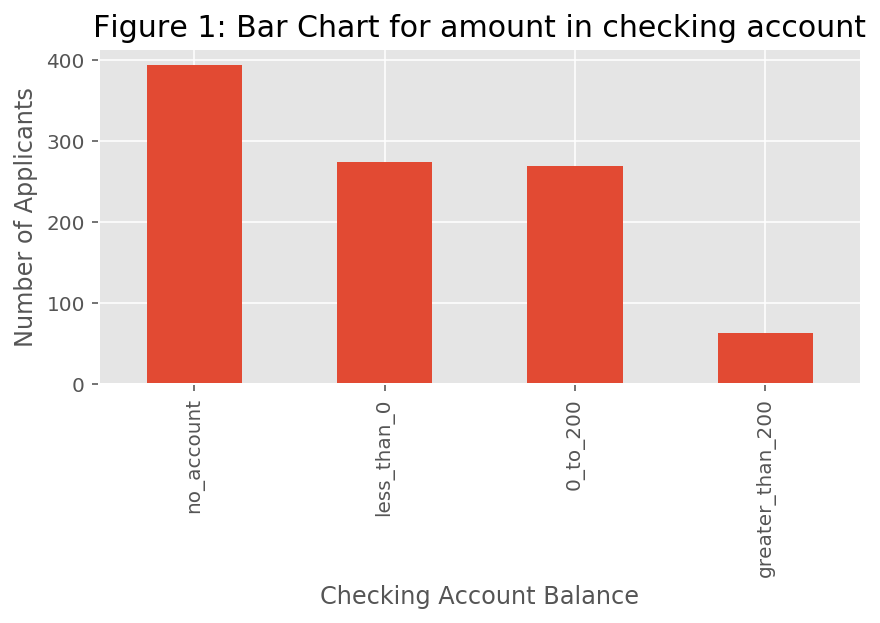

```python
plot1 = crdt_cat['checking_status'].value_counts().plot(kind = 'bar')
plot1.set_xticklabels(plot1.get_xticklabels(), rotation = 90)
plt.tight_layout()
plt.title('Figure 1: Bar Chart for amount in checking account', fontsize = 15)
plt.xlabel('Checking Account Balance')
plt.ylabel('Number of Applicants')
plt.show();
```

Observably, while around 400 people who applied for credit do not have an active checking account and for the ones who have it, the status of existing checking account is greater than 200 Marks for a very less percentage of people. About half of the total applicants are equally divided between having a negative balance and a balance between 0-200 Marks.

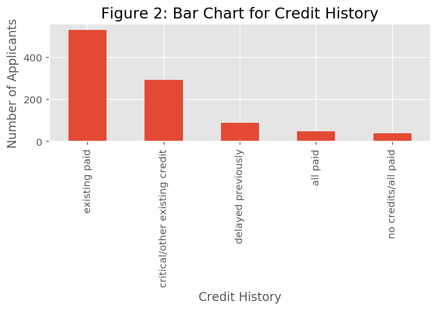

```python
plot2 = crdt_cat['credit_history'].value_counts().plot(kind = 'bar')
plot2.set_xticklabels(plot2.get_xticklabels(), rotation = 90)
plt.tight_layout()
plt.title('Figure 2: Bar Chart for Credit History', fontsize = 15)
plt.xlabel('Credit History')
plt.ylabel('Number of Applicants')
plt.show();
```

The existing credit is paid by almost half of the applicants, approximately 300 people have critical or other existing credit. Almost 10% of total applicants have recorded previous delays in credit payment and a very minute percentage of applicants have all paid or no credit history.

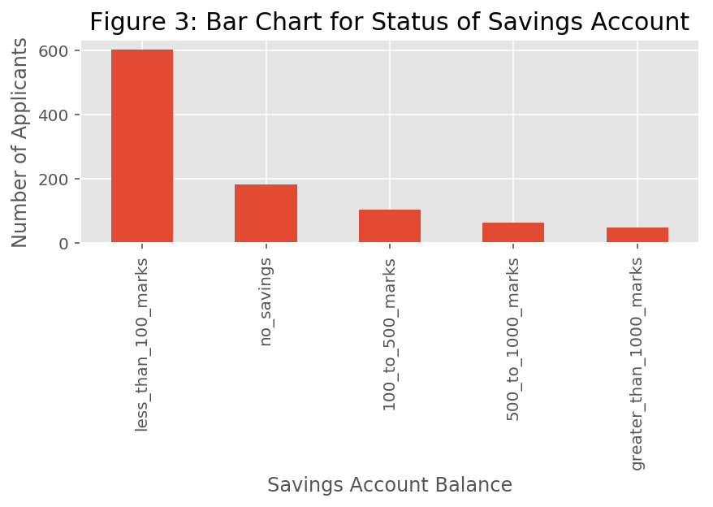

```python
plot3 = crdt_cat['savings_status'].value_counts().plot(kind = 'bar')
plot3.set_xticklabels(plot3.get_xticklabels(), rotation = 90)
plt.tight_layout()
plt.title('Figure 3: Bar Chart for Status of Savings Account', fontsize = 15)
plt.xlabel('Savings Account Balance')
plt.ylabel('Number of Applicants')
plt.show();
```

According to the graph, almost 600 applicants have less than 100 Marks in their savings account, approximately 175 applicants have no savings, almost 100 of them have 100-500 Marks and very less applicants have more than 500 and 1000 Marks in their saving accounts.

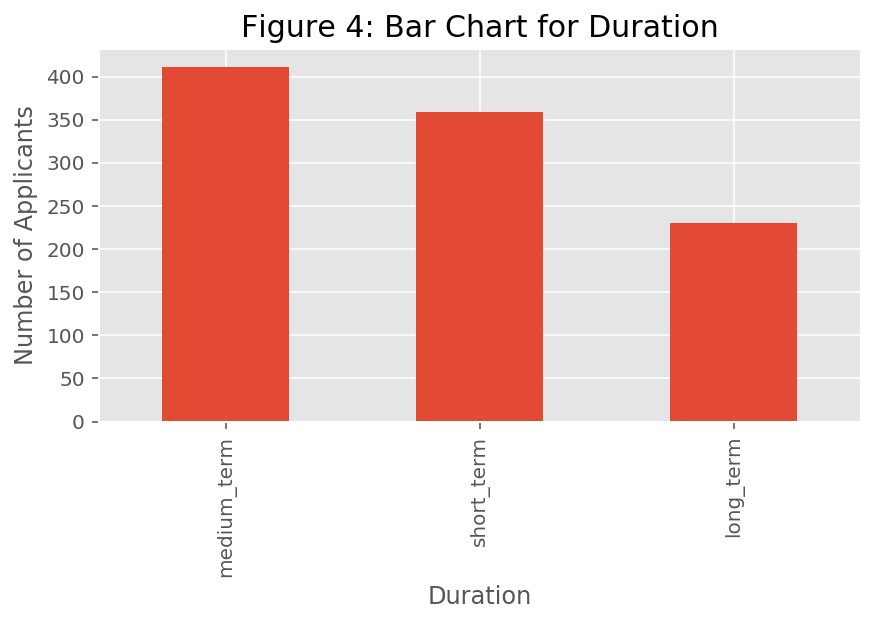

```python
plot4 = crdt_cat['duration'].value_counts().plot(kind = 'bar')
plot4.set_xticklabels(plot4.get_xticklabels(), rotation = 90)
plt.tight_layout()
plt.title('Figure 4: Bar Chart for Duration', fontsize = 15)
plt.xlabel('Duration')
plt.ylabel('Number of Applicants')
plt.show();
```

As we can see, around 400 apploicants have applied for medium term, around 360 of them have applied for short term and around 225 people applied for a long term duration.

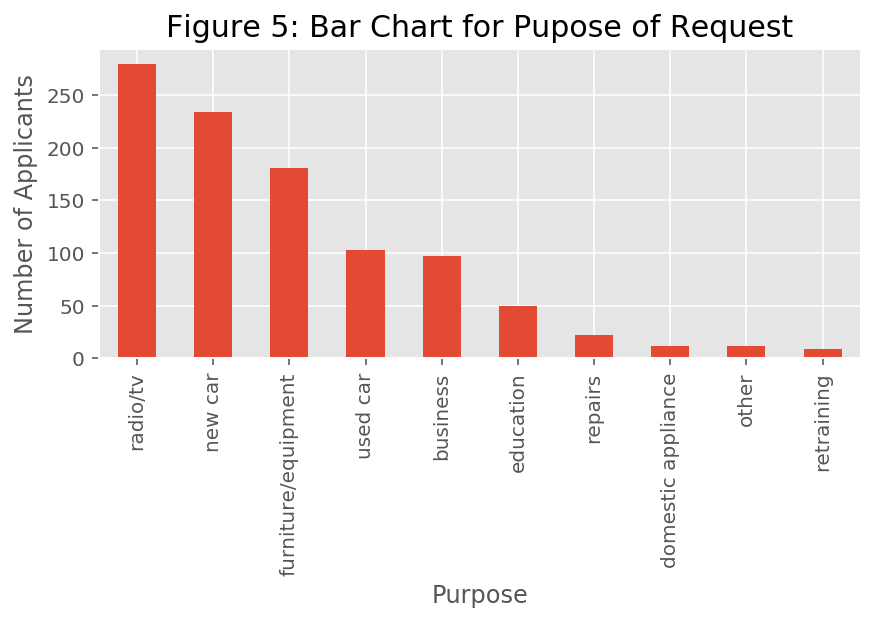

```python
plot5 = crdt_cat['purpose'].value_counts().plot(kind = 'bar')
plot5.set_xticklabels(plot5.get_xticklabels(), rotation = 90)
plt.tight_layout()
plt.title('Figure 5: Bar Chart for Pupose of Request', fontsize = 15)
plt.xlabel('Purpose')
plt.ylabel('Number of Applicants')
plt.show();
```

We can infer that radio/tv was the most popular item for which people filed credit application, new car being the second, furniture and equipments being the third and used car being the fourth most popular item. Fewer applicants want the credit amount for a business investment and education puposes. The least popular requests are for repairs, domestic appliances and retraining.

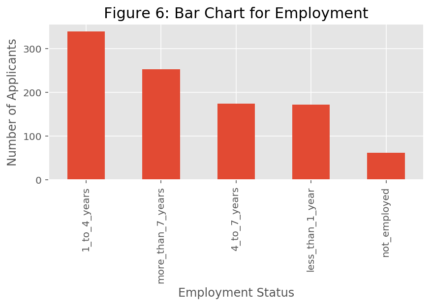

```python
plot6 = crdt_cat['employment'].value_counts().plot(kind = 'bar')
plot6.set_xticklabels(plot6.get_xticklabels(), rotation = 90)
plt.tight_layout()
plt.title('Figure 6: Bar Chart for Employment', fontsize = 15)
plt.xlabel('Employment Status')
plt.ylabel('Number of Applicants')
plt.show();
```

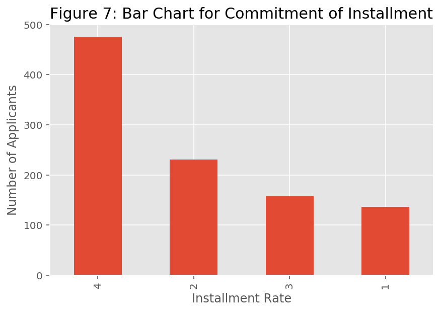

```python
plot6 = crdt_cat['installment_commitment'].value_counts().plot(kind = 'bar')
plot6.set_xticklabels(plot6.get_xticklabels(), rotation = 90)
plt.tight_layout()
plt.title('Figure 7: Bar Chart for Commitment of Installment', fontsize = 15)
plt.xlabel('Installment Rate')
plt.ylabel('Number of Applicants')
plt.show();
```

We may infer that almost half of the applicants preferred to pay 4 percent rate on installments, almost 230 applicants preferred 2 percent, approximately 150 preferred 3 percent and around 130 preferred a 1 percent.

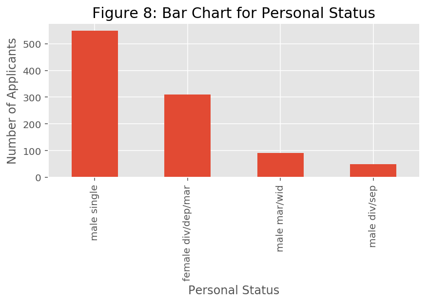

```python
plot7 = crdt_cat['personal_status'].value_counts().plot(kind = 'bar')
plot7.set_xticklabels(plot7.get_xticklabels(), rotation = 90)
plt.tight_layout()
plt.title('Figure 8: Bar Chart for Personal Status', fontsize = 15)
plt.xlabel('Personal Status')
plt.ylabel('Number of Applicants')
plt.show();
```

As shown by the graph above, almost half of the applicants are single male, 300 are females who are divorced/departed/married, 100 are married/widowed male and 50 applicants are divorced/separated male.

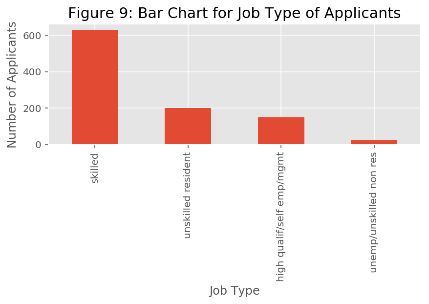

```python
plot8 = crdt_cat['job'].value_counts().plot(kind = 'bar')
plot8.set_xticklabels(plot8.get_xticklabels(), rotation = 90)
plt.tight_layout()
plt.title('Figure 9: Bar Chart for Job Type of Applicants', fontsize = 15)
plt.xlabel('Job Type')
plt.ylabel('Number of Applicants')
plt.show();
```

According to the graph, more than half of the applicants are skilled workers, almost 200 of them are unskilled residents, around 150 are highly qualified/self-employed and very few are unemployed/unskilled non-residents.

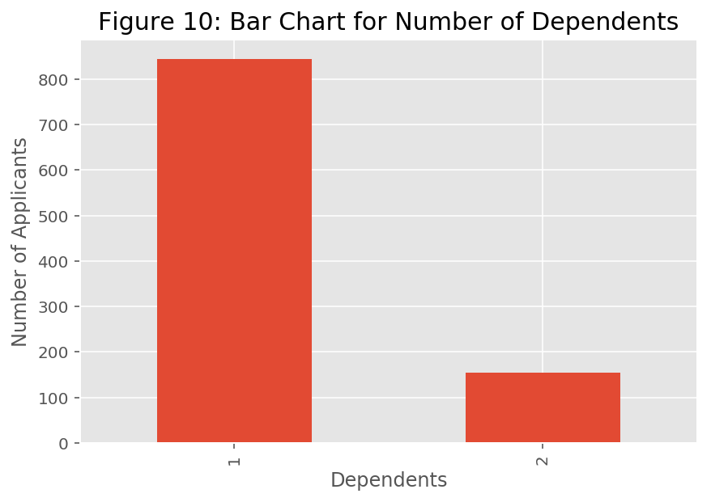

```python
plot9 = crdt_cat['num_dependents'].value_counts().plot(kind = 'bar')
plot9.set_xticklabels(plot9.get_xticklabels(), rotation = 90)
plt.tight_layout()
plt.title('Figure 10: Bar Chart for Number of Dependents', fontsize = 15)
plt.xlabel('Dependents')
plt.ylabel('Number of Applicants')
plt.show();
```

Maximum applicants have a single dependent and very few have 2 dependents.

### 4.2 Two-variable Plots

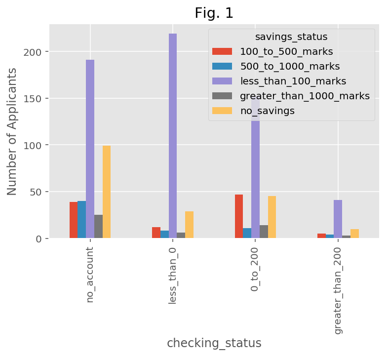

```python
grp = crdt_cat[['savings_status','checking_status']].groupby(['checking_status','savings_status'])
myorder = ['no_account','less_than_0','0_to_200','greater_than_200']
recorded = grp.size().reindex(myorder,level=0)
recorded.unstack().plot.bar()
plt.title('Fig. 1')
plt.ylabel('Number of Applicants')
```

Graph observations:

- Applicants with no checking accounts: Almost 190 applicants have less than 100 Marks in savings account, 100 applicants have no savings and rest have 100-500 or 500-1000 or greater than 1000 Marks in their savings account.
- Applicants with negative checking balance: More than 200 have less than 100 Marks in savings account, few applicants have no savings, 100-500, 500-1000 or greater than 1000 Marks in savings.
- Applicants with 0-200 Marks in checking account: Maximum people have less than 100 Marks in savings account, around 50 applicants have no savings and 100-500 Marks and rest have no savings, 500-1000 and greater than 1000 Marks in savings account.
- Applicants with greater than 200 Marks in checking account: Maximum have less than 100 Marks in savings and very few have no savings, 100-500, 500-1000 and greater than 1000 Marks in savings account.

Maximum people have less than 100 Marks in savings account irrespective of their checking account status.

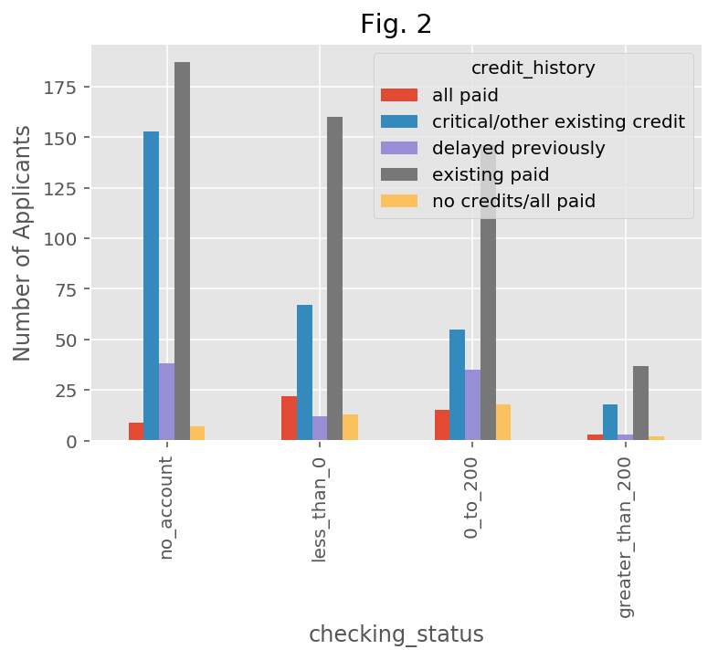

```python
grp = crdt_cat[['credit_history','checking_status']].groupby(['checking_status','credit_history'])
myorder = ['no_account','less_than_0','0_to_200','greater_than_200']
recorded = grp.size().reindex(myorder,level=0)
recorded.unstack().plot.bar()
plt.title('Fig. 2')
plt.ylabel('Number of Applicants')
```

Graph Observations:

- Applicants with no checking accounts: Maximum people either have paid existing credit or have critical/other existing credit history and rest have delayed, all paid or no credit history.
- Applicants with negative checking balance: Maximum people have paid existing credit, fewer people have critical/other existing credit history and rest have delayed, all paid or no credit history.
- Applicants with 0-200 Marks in checking account: Maximum applicants have paid existing credit, few have critical/other existing credit history and fewer have delayed, all paid or no credit history.
- Applicants with greater than 200 Marks in checking account: Most applicants either have paid existing credit or have critical/other existing credit history and others have delayed, all paid or no credit history.

Maximum people having paid their existing credits irrespective of their checking account status.

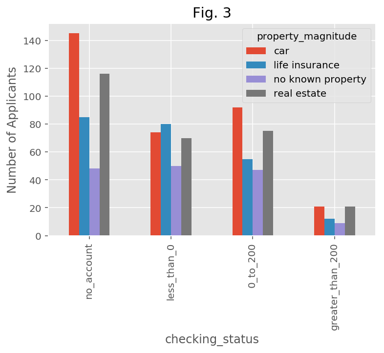

```python
grp = crdt_cat[['property_magnitude','checking_status']].groupby(['checking_status','property_magnitude'])
myorder = ['no_account','less_than_0','0_to_200','greater_than_200']
recorded = grp.size().reindex(myorder,level=0)
recorded.unstack().plot.bar()
plt.title('Fig. 3')
plt.ylabel('Number of Applicants')
```

Graph Observations:

- Applicants with no checking accounts: Maximum applicants own a car, more than 100 have real estate property, around 80 have a life insurance and almost 50 people have no registered investments.
- Applicants with negative checking balance: Almost 80 applicants own a car, approximately 70 have real estate property, around 80 have a life insurance and almost 50 people have no registered investments.
- Applicants with 0-200 Marks in checking account: Maximum people own a car, around 70 have real estate property, around 55 have a life insurance and almost 50 people have no registered investments.
- Applicants with greater than 200 Marks in checking account: Maximum applicants either own a car or have real estate property, very few either have a life insurance or no registered investments.

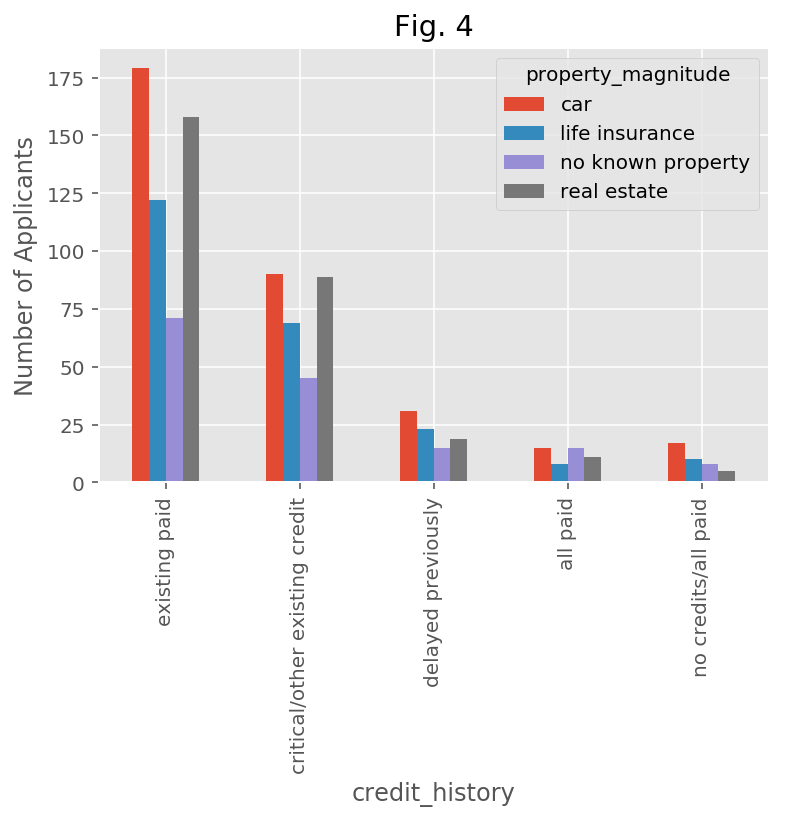

```python
grp = crdt_cat[['property_magnitude','credit_history']].groupby(['credit_history','property_magnitude'])
myorder = ['existing paid','critical/other existing credit','delayed previously','all paid','no credits/all paid']
recorded = grp.size().reindex(myorder,level=0)
recorded.unstack().plot.bar()
plt.title('Fig. 4')
plt.ylabel('Number of Applicants')
```

Graph Observations:

People with all kinds of credit histories own a car.

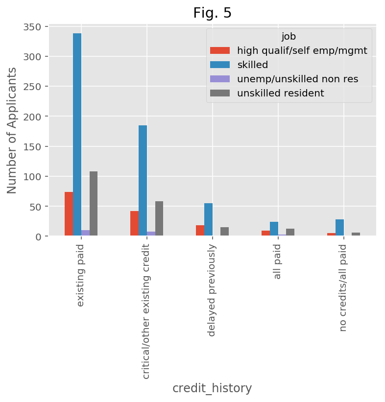

```python
grp = crdt_cat[['job','credit_history']].groupby(['credit_history','job'])
myorder = ['existing paid','critical/other existing credit','delayed previously','all paid','no credits/all paid']
recorded = grp.size().reindex(myorder,level=0)
recorded.unstack().plot.bar()
plt.title('Fig. 5')
plt.ylabel('Number of Applicants')
```

Graph Observations:

Most people are skilled irrespective of their credit history.

### 4.3 Three-variable Plots

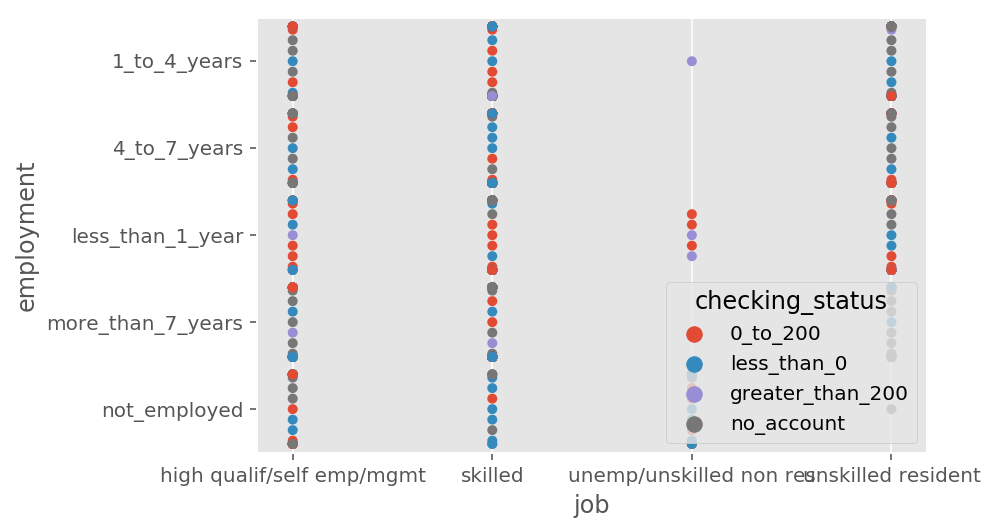

```python
sns.swarmplot(x='job', y='employment', data=crdt_cat,
              hue='checking_status')
```

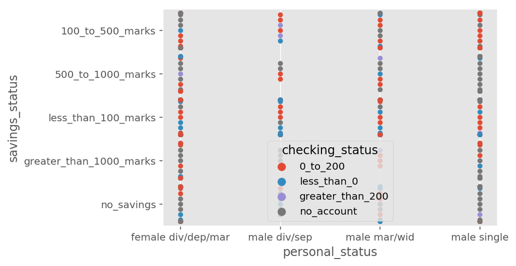

```python
sns.swarmplot(x='personal_status', y='savings_status', data=crdt_cat,
              hue='checking_status')
```

Inferences:

- Divorced/departed/married Female:
  - Applicants with no savings account: Most people do not have a checking account, few have 0-200 or less than 0 Marks.
  - Applicants having greater than 1000 Marks: Most people either do not have a checking account, have 0-200 Marks or negative balance.
  - Applicants having less than 100 Marks: Maximum people have 0-200 or less than 0 Marks in checking account, some have no account.
  - Applicants having 500-1000 Marks: Most either have 0-200 Marks or no checking account, some have negative balance and very few have greater than 200 Marks.
  - Applicants having 100-500 Marks: Maximum do not have a checking account, some have 0-200 Marks and few have less than 0 balance.
- Divorced/separated Male:
  - Applicants with no savings account: Maximum have either negative or 0-200 account balance.
  - Applicants having greater than 1000 Marks: People in this category either have no account or 0-200 Marks in their account.
  - Applicants having less than 100 Marks: Most people have negative balance and rest have 0-200 Marks in checking account.
  - Applicants having 500-1000 Marks: People either have 0-200 or no checking account at all.
  - Applicants having 100-500 Marks: Most people have 0-200, some have greater than 200 and rest have negative checking account balance.
- Married/widowed Male:
  - Applicants with no savings account: Most people either have negative balance or no checking account. Few have 0-200 Marks in their account.
  - Applicants having greater than 1000 Marks: Most have 0-200 Marks in checking account, few have negative balance.
  - Applicants having less than 100 Marks: Maximum either have 0-200 or less than 0 Marks and few don't have an account.
  - Applicants having 500-1000 Marks: Most do not have an account or have 0-200 balance. Few have negative or greater than 200 balance.
  - Applicants having 100-500 Marks: People either have 0-200 balance or do not own a checking account.
- Single Male:
  - Applicants with no savings account: Most applicants do not have an account and very few have greater than 200 checking balance.
  - Applicants having greater than 1000 Marks: People either have negative balance, 0-200 Marks or do not have an account.
  - Applicants having less than 100 Marks: Most have 0-200 Marks, lesser have less than 0 and few don't have checking accounts.
  - Applicants having 500-1000 Marks: Most people do not have a checking account.
  - Applicants having 100-500 Marks: Maximum have 0-200 balance and very few have negative balance.